# VEGANScreener + metabolomics

Q2+: Associations between VS_total_plus and the metabolome in vegans.

**This code is used to explore patterns in the metabolome profiles of vegans, particularly by linking them to the VEGANScreener score + (VS_total_plus).**

The script is divided into two parts, according to the integration method of metabolome datasets (see preprocessing scripts for details). At first, the **sPCA dataset** is analyzed. This dataset is used for multivariate analysis, PCA visualization, PERMANOVA and ML approach. The **concatenated dataset** of both LCMS and NMR is used for univariate analysis.

The main parts of the analysis is composed of:

1. Global visualization - 3 components color-coding **VS_total_plus**
2. PERMANOVA - how much of the variation can be explained by various external variables: dist(Metabolome) ~ sex + bmi + age + veganDuration + country***VS_total_plus**
3. Univariate analysis (feature-wise model) - linear modelling of metabolite using various external variables: Metabolite ~ sex + bmi + age + veganDuration + Country***VS_total_plus**
4. Random fores (RF) classification - the model is trained and validated through bootstrapping with 500 iterations. The RF model is used to distinguish between participants with **1st and 3rd tercile of VS_total_plus**. The two types of models are trained:
1. ML model on original sPCA dataset
2. ML model on sPCA dataset after regressing out the covariates.

# 1 Import

```r
metadata_df <- read.table(
  file =  "../../data/preprocessed/metadata_preprocessed_v3.tsv",
  header = TRUE) %>% dplyr::filter(!is.na(VS_total_plus))

lcms_df <- read.table(
  file= "../../data/preprocessed/metabolomics/lc_ms_preprocessed_INT_v3.tsv",
  check.names = FALSE) %>% dplyr::filter(rownames(.) %in% metadata_df$study_id)

nmr_df <- read.table(
  file = "../../data/preprocessed/metabolomics/nmr_preprocessed_INT_v3.tsv",
  check.names = FALSE) %>% dplyr::filter(rownames(.) %in% metadata_df$study_id)

spca_integrated_df <-  read.table(
  file = "../../data/preprocessed/metabolomics/spca_integrated_vegans_INT_v3.tsv",
  check.names = FALSE) %>% dplyr::filter(rownames(.) %in% metadata_df$study_id)
```

```r
metadata_scaled_df <- metadata_df
metadata_scaled_df[,-c(1,3,5,6,8)] <- apply(metadata_df[,-c(1,3,5,6,8)],2,scale)
metadata_scaled_df <- metadata_scaled_df %>%
  mutate(sex=as.factor(sex),
         country=as.factor(country),
         group=as.factor(group),
         diet_supplements=as.factor(diet_supplements))
```

# 2 Descriptive statistics

Summary of counts per diet group, country and sex:

```r
metadata_df %>% dplyr::group_by(country,sex) %>% count()
```

```
# A tibble: 10 × 3
# Groups:   country, sex [10]
   country sex       n
   <chr>   <chr> <int>
 1 BE      F        53
 2 BE      M        28
 3 CH      F        23
 4 CH      M        20
 5 CZ      F        50
 6 CZ      M        41
 7 DE      F        51
 8 DE      M        47
 9 ES      F        28
10 ES      M        15
```

Basic plots for visualizing the distribution of selected variables:

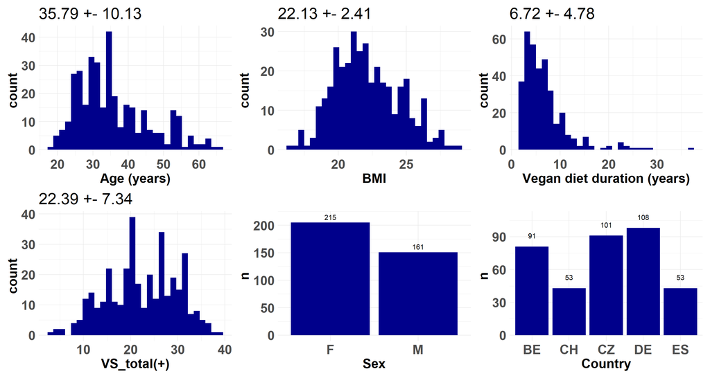

```r
plot_list <- list()
name <- c("Age (years)","BMI","Vegan diet duration (years)","VS_total(+)")
i <- 1
for (col in c("age","bmi","vegan_duration","VS_total_plus")){
  p <- ggplot(metadata_df) +
    geom_histogram(aes(x=!!sym(col)),fill="darkblue") +
    theme_minimal() +
    theme(axis.title = element_text(face="bold",size=20),
          axis.text=element_text(face="bold",size=20),
          title = element_text(face = "plain",size=20)) +
    xlab(name[i]) +
    ggtitle(paste(round(mean(metadata_df[,col],na.rm = TRUE),2),"+-", round(sd(metadata_df[,col],na.rm = TRUE),2)))

  plot_list[[length(plot_list)+1]] <- p
  i <- i + 1

}
i <- 1
name <- c("Sex","Country")
for (col in c("sex","country")){
  p <- ggplot(metadata_df) +
        theme_minimal() +
     theme(axis.title = element_text(face="bold",size=20),
          axis.text=element_text(face="bold",size=20)) +
    stat_count(aes(x=!!sym(col)),fill="darkblue") +
  geom_text(data=metadata_df %>%
              dplyr::group_by(!!sym(col)) %>% count() %>%
              dplyr::mutate(n=n+10), aes(x=!!sym(col),y=n,label=n)) +
    xlab(name[i])

  plot_list[[length(plot_list)+1]] <- p

  i <- i+1
}

wrap_plots(plot_list)
```

# 3 SPCA

The SPCA dataset was created by concatenating LCMS and NMR dataset and applying Mixomics::spca() function. See preprocessing script for details.

mixOmics::spca() performs **Sparse Principal Component Analysis**, which is similar to regular PCA but adds a sparsity constraint so that only a subset of variables contributes to each component. This sparsity is controlled by penalization, making interpretation easier because irrelevant or noisy variables get loadings of zero.

## 3.1 Visualization

### 3.1.1 PCA

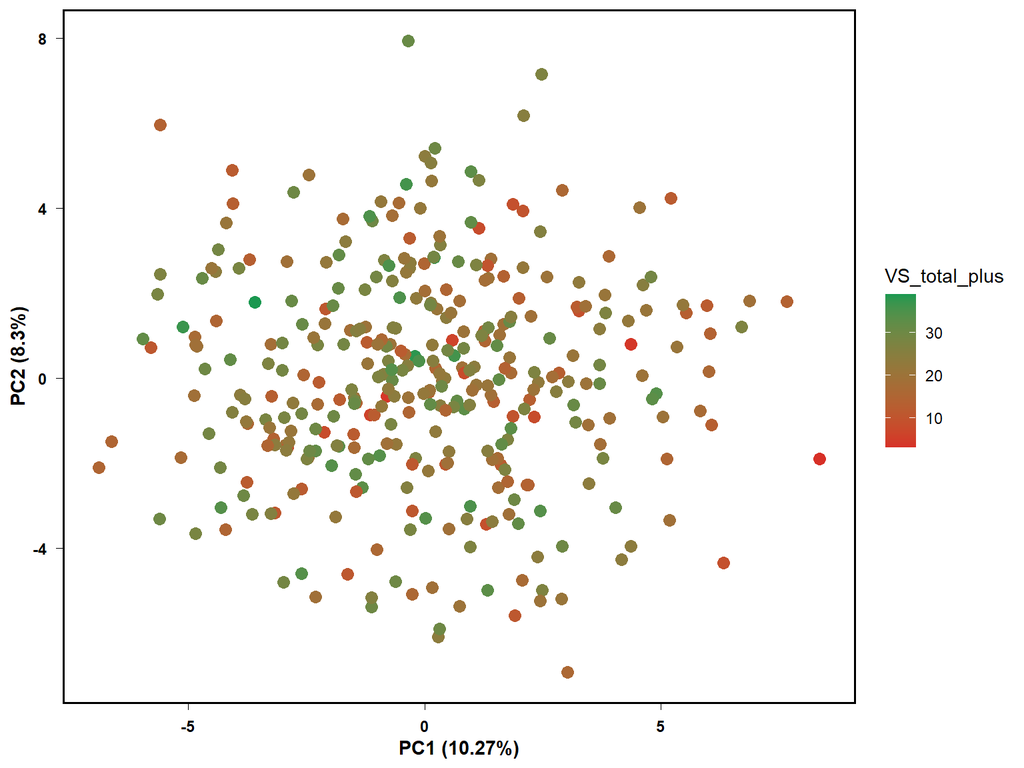

```r
spca_plot_df <- merge(
  spca_integrated_df %>% rownames_to_column("study_id"),
  metadata_df,by="study_id")

p <- pca_plot(spca_integrated_df,
              metadata_df,
              color_col = "VS_total_plus",
              perform_pca = FALSE)

p <- ggtheme(p)

p
```

```r
p_pca <- list()
p_pca[[1]] <- p
```

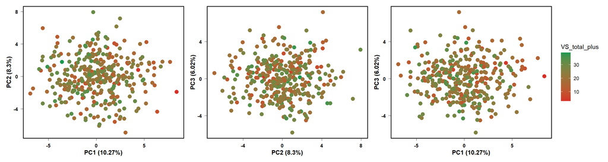

```r
spca_plot_df <- merge(
  spca_integrated_df %>% rownames_to_column("study_id"),
  metadata_df,by="study_id")

p1 <- pca_plot(spca_integrated_df,
              metadata_df,
              color_col = "VS_total_plus",
              perform_pca = FALSE,axis = c("PC1","PC2"))

p1 <- ggtheme(p1)

p2 <- pca_plot(spca_integrated_df,
              metadata_df,
              color_col = "VS_total_plus",
              perform_pca = FALSE,axis = c("PC2","PC3"))

p2 <- ggtheme(p2)

p3 <- pca_plot(spca_integrated_df,
              metadata_df,
              color_col = "VS_total_plus",
              perform_pca = FALSE,axis = c("PC1","PC3"))

p3 <- ggtheme(p3)

p1 + p2 + p3 +
plot_layout(guides = "collect")
```

### 3.1.2 Boxplots

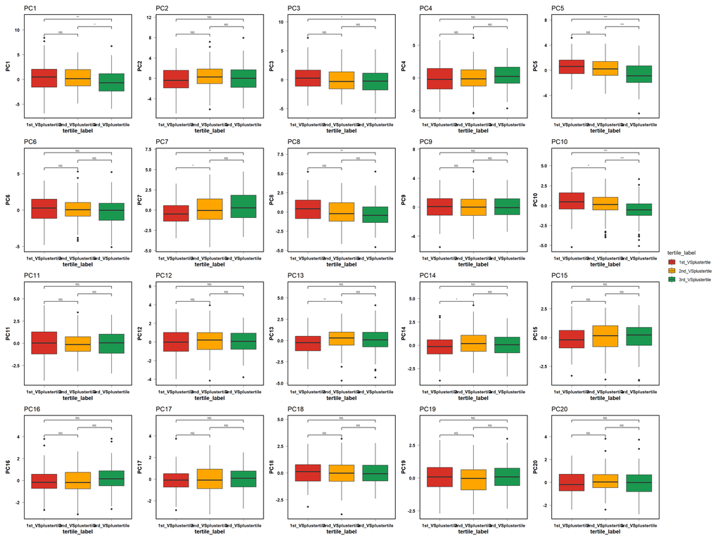

```r
spca_for_uni <- merge(spca_integrated_df %>% rownames_to_column("study_id"),
                      metadata_scaled_df,by="study_id",all = TRUE)

spca_for_uni <- spca_for_uni %>%
  mutate(
    tertile_cut = ntile(VS_total_plus, 3), # assign 1, 2, or 3 (tertile)
    tertile_label = case_when(                          # label tertiles
      tertile_cut == 1 ~ "1st_VSplustertile",
      tertile_cut == 2 ~ "2nd_VSplustertile",
      tertile_cut == 3 ~ "3rd_VSplustertile"
    )
  )

plot_list <- list()
for (col in colnames(spca_integrated_df)){
  p <- ggplot(spca_for_uni,
              aes_string(x = "tertile_label",y = col,fill="tertile_label")) +
    geom_boxplot() +
    ggtitle(col) +
    theme_minimal() +
    scale_fill_manual(values = c("#D73027","orange","#1A9850")) +
    geom_signif(comparisons =
                  combn(as.character(unique(spca_for_uni$tertile_label)),
                        m=2, simplify = FALSE),
                map_signif_level = TRUE, step_increase = 0.1,textsize = 2)

  p <- ggtheme(p)
  plot_list[[length(plot_list) + 1]] <- p
}


a <- wrap_plots(plot_list,guides = "collect")

a
```

### 3.1.3 Heatmap

```r
metadata_df <- metadata_df %>%
  mutate(
    tertile_cut = ntile(VS_total_plus, 3), # assign 1, 2, or 3 (tertile)
    tertile_label = case_when(                          # label tertiles
      tertile_cut == 1 ~ "1st_VSplustertile",
      tertile_cut == 2 ~ "2nd_VSplustertile",
      tertile_cut == 3 ~ "3rd_VSplustertile"
    )
  ) %>%
  dplyr::select(-tertile_cut)
```

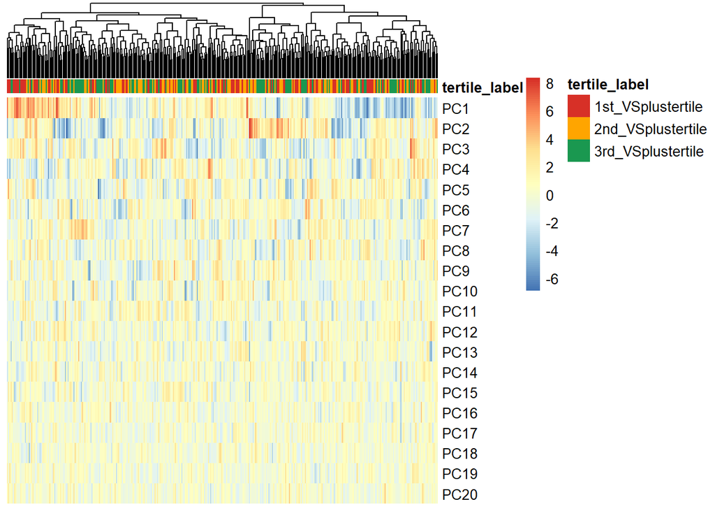

```r
VS_colors <- c("1st_VSplustertile"="#D73027",
               "2nd_VSplustertile"="orange",
               "3rd_VSplustertile"="#1A9850")

p_df <- spca_integrated_df %>% t()

ann_df <- metadata_df %>% dplyr::select(study_id,tertile_label) %>%
  column_to_rownames("study_id")

ann_colors <- list(
  "tertile_label"=VS_colors
)
names(ann_colors[["tertile_label"]]) <- names(VS_colors)

p <- pheatmap(p_df,cluster_rows = FALSE,show_colnames = FALSE,
              annotation_col = ann_df,
              annotation_colors = ann_colors,silent = TRUE)

p
```

**Tertile averages**

```r
metadata_df %>%
  dplyr::select(VS_total_plus, tertile_label) %>%
  group_by(tertile_label) %>%
  summarise(mean_VSplus = mean(VS_total_plus, na.rm = TRUE))
```

```
# A tibble: 3 × 2
  tertile_label     mean_VSplus
  <chr>                   <dbl>
1 1st_VSplustertile        14.1
2 2nd_VSplustertile        22.6
3 3rd_VSplustertile        30.5
```

## 3.2 PERMANOVA

The test show how much of the variation in metabolomics is explained by: sex - age - bmi -vegan duration - Country - **VS_total_plus**

Variables were added sequentially (Type I SS), so each p-value and R² reflects a partial effect, after adjusting for those above. This model accounts for variation due to sex, age, vegan diet duration, BMI and country of origin. Then accounts for the main effects of VS_total. Then tests whether the effect of VS_total varies by country of origin (interaction).

However, the country of origin is still explaining the most of the variation ~ **10%**. The interaction effect is not significant, which suggest the differences in VS_total is not inconsistent throughout the countries.

```r
# Create Euclidean distance matrix
dist_mat <- vegdist(spca_integrated_df,
                    method = "euclidean")

# Test whether vegan vs omnivore differ in metabolomics
adonis_result <- adonis2(
  dist_mat ~ sex + bmi + age + vegan_duration + country*VS_total_plus,
  data = metadata_scaled_df ,
  permutations = 999,
  by="terms")

print(adonis_result)
```

```
Permutation test for adonis under reduced model
Terms added sequentially (first to last)
Permutation: free
Number of permutations: 999

adonis2(formula = dist_mat ~ sex + bmi + age + vegan_duration + country * VS_total_plus, data = metadata_scaled_df, permutations = 999, by = "terms")
                       Df SumOfSqs      R2       F Pr(>F)
sex                     1   1105.2 0.05640 24.1322  0.001 ***
bmi                     1    168.1 0.00858  3.6699  0.001 ***
age                     1    250.9 0.01280  5.4791  0.001 ***
vegan_duration          1     51.7 0.00264  1.1299  0.304
country                 4   1856.5 0.09473 10.1343  0.001 ***
VS_total_plus           1    352.7 0.01800  7.7016  0.001 ***
country:VS_total_plus   4    149.0 0.00760  0.8133  0.856
Residual              342  15662.9 0.79925
Total                 355  19597.1 1.00000
---
Signif. codes:  0 '***' 0.001 '**' 0.01 '*' 0.05 '.' 0.1 ' ' 1
```

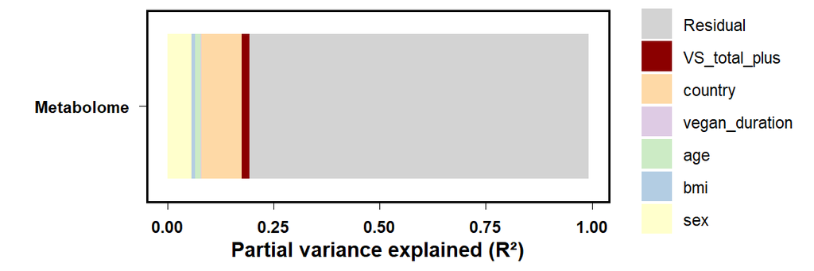

```r
adonis_result <- adonis_result[-c(7,9),] %>% rownames_to_column("Var")
adonis_result$Var <- factor(adonis_result$Var,levels = rev(c("sex","bmi","age", "vegan_duration","country","VS_total_plus", "Residual")))
p <- ggplot(adonis_result, aes(fill=Var, x=R2, y="Metabolome")) +
    geom_bar(position="stack", stat="identity") +
  ylab("") + xlab("Partial variance explained (R²)") +
  scale_fill_manual(values=rev(c("#ffffcc","#b3cde3","#ccebc5",
                                 "#decbe4","#fed9a6","darkred",
                                 "lightgrey")),name = "Covariate")

p <- ggtheme(p)

p
```

```r
p_pca[[2]] <- p
p_pca[[3]] <- adonis_result
```

## 3.3 RF model

### 3.3.1 Original model

```r
sub_metadata_df <- metadata_df %>%
dplyr::filter(
  tertile_label %in% c("1st_VSplustertile","3rd_VSplustertile"))

sub_spca_integrated_df <- spca_integrated_df[as.character(sub_metadata_df$study_id),]
```

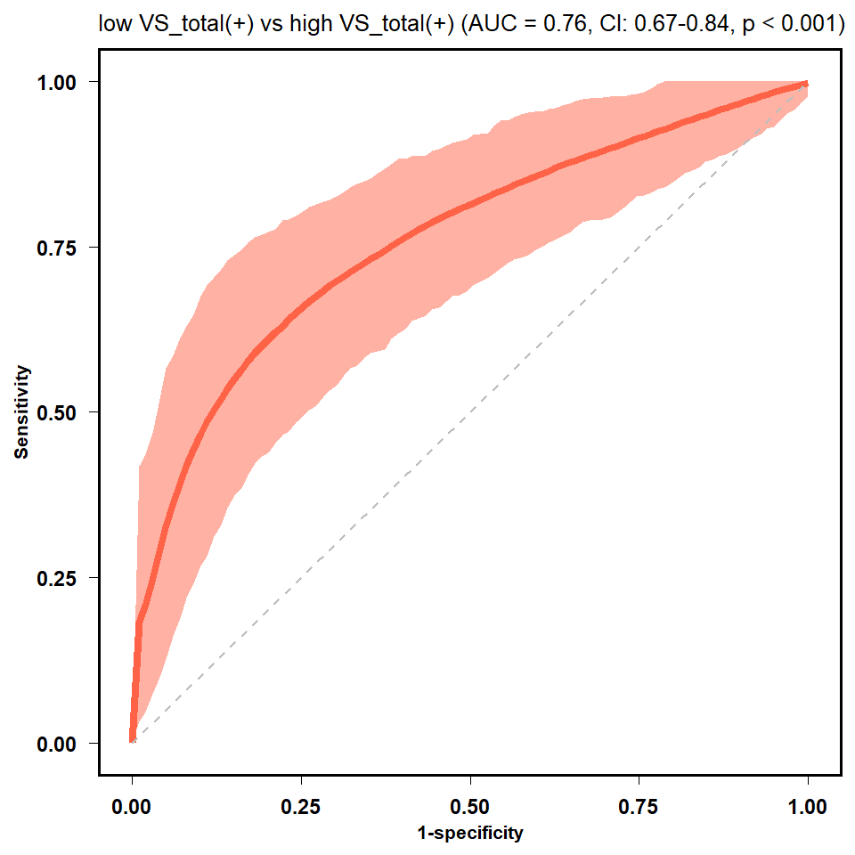

```r
model_name <- "VSplus_tertile_vegan"

prepared_df <- model_preparation(sub_spca_integrated_df,
                                 sub_metadata_df,
                                 predicting_col = "tertile_label")

rf_model <- make_rf_model(data=prepared_df,
                            outcome="Group",
                            N = 500,
                           file = model_name,
                            reuse=TRUE)

roc_c <- roc_curve(model_object = rf_model,
                   group = c("low VS_total(+)","high VS_total(+)"),CI = TRUE)

roc_c <- ggtheme(roc_c) +
  theme(legend.position="none",title = element_text(size=8))

roc_c
```

**Accuracy**

```r
# Find the "best" threshold using Youden's J Index
# This maximizes (Sensitivity + Specificity - 1)
roc_obj <- rf_model$rocobj
best_threshold_data <- coords(roc_obj, "best",
                              ret = "threshold",
                              best.method = "youden")
optimal_threshold <- best_threshold_data$threshold
optimal_threshold
```

```
[1] 0.5106333
```

```r
# saving the results
save_rf_details("../results/vegan/RF_models_performance.xlsx",model_name,rf_model)
```

```
[1] "Results saved to ../results/vegan/RF_models_performance.xlsx"
```

### 3.3.2 Adjusted model

```r
# Covariates to adjust for
covars <- c("sex","bmi", "age", "country", "vegan_duration")
integrated_df <- sub_spca_integrated_df
all(rownames(integrated_df) == sub_metadata_df$study_id)
```

```
[1] TRUE
```

```r
adjusted_data <- adjust_for_covars(integrated_df, covars, sub_metadata_df)

model_name <- "adjusted_vstotalplus_model_vegan"

prepared_df <- model_preparation(adjusted_data,
                                 sub_metadata_df,
                                 predicting_col = "tertile_label")

rf_model <- make_rf_model(data=prepared_df,
                          outcome="Group",
                          N = 500,
                          file = model_name,
                          reuse=TRUE)

rf_model$model_summary
```

```
  mtry splitrule min.node.size       auc  accuracy   auc_CIL   auc_CIU
1    3      gini             2 0.6951126 0.6451807 0.6052005 0.7785791
  accuracy_CIL accuracy_CIU
1    0.5465853    0.7317084
```

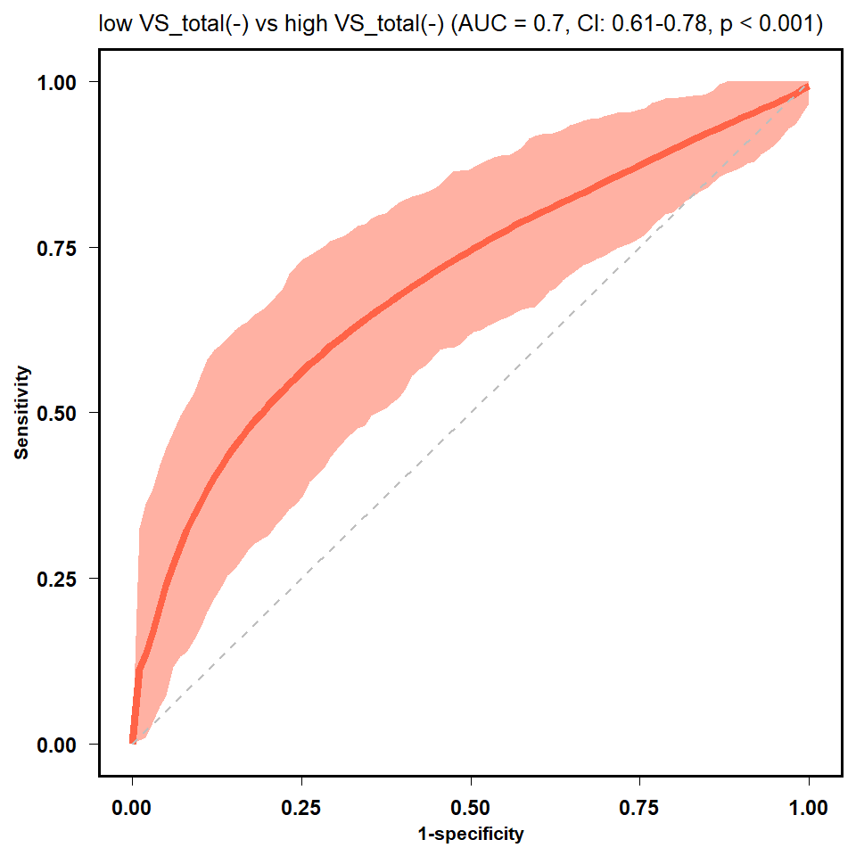

```r
roc_c <- roc_curve(model_object = rf_model,
                   group = c("low VS_total(-)","high VS_total(-)"),CI = TRUE)

roc_c <- ggtheme(roc_c) +
  theme(legend.position="none",title = element_text(size=8))

roc_c
```

```r
# Find the "best" threshold using Youden's J Index
# This maximizes (Sensitivity + Specificity - 1)
roc_obj <- rf_model$rocobj
best_threshold_data <- coords(roc_obj, "best",
                              ret = "threshold",
                              best.method = "youden")
optimal_threshold <- best_threshold_data$threshold
optimal_threshold
```

```
[1] 0.509
```

```r
# saving the results
save_rf_details("../results/vegan/RF_models_performance.xlsx",model_name,rf_model)
```

```
[1] "Results saved to ../results/vegan/RF_models_performance.xlsx"
```

## 3.4 RF importance

### 3.4.1 Original model

**PC5** and **PC10** are the most important for RF model.

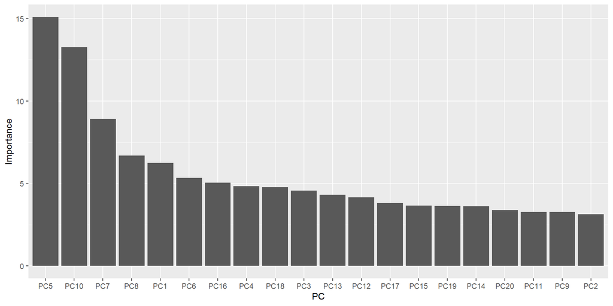

```r
load("../intermediate_files/models/VSplus_tertile_vegan/rf_model.RData")

var_imp <- as.data.frame(importance(rf_model$trained_model)) %>%
  rownames_to_column("PC") %>%
  `colnames<-`(c("PC","Importance"))

var_imp <- var_imp %>% dplyr::mutate(PC=factor(PC,levels = PC[order(var_imp$Importance,decreasing = TRUE)]))

ggplot(var_imp) +
  geom_col(aes(x=PC,y=Importance))
```

### 3.4.2 Adjusted model

Similarly as above, the most important is **PC5**, with significant drop of importance after this PC.

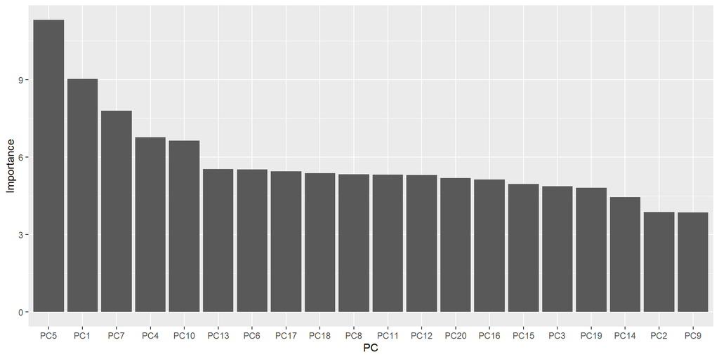

```r
load("../intermediate_files/models/adjusted_vstotalplus_model_vegan/rf_model.RData")

var_imp <- as.data.frame(importance(rf_model$trained_model)) %>%
  rownames_to_column("PC") %>%
  `colnames<-`(c("PC","Importance"))

var_imp <- var_imp %>% dplyr::mutate(PC=factor(PC,levels = PC[order(var_imp$Importance,decreasing = TRUE)]))

ggplot(var_imp) +
  geom_col(aes(x=PC,y=Importance))
```

### 3.4.3 Visualization

To explore the important PCs, their visualization is shown below. We will show **PC5**, as it was consistently picked by two models and **PC10** as this PC remained in the list of the most important PCs after adjustment.

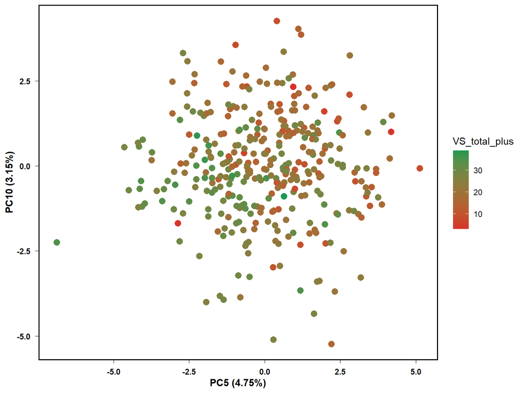

```r
spca_plot_df <- merge(
  spca_integrated_df %>% rownames_to_column("study_id"),
  metadata_df,by="study_id")

p <- pca_plot(spca_integrated_df,
              metadata_df,
              color_col = "VS_total_plus",
              perform_pca = FALSE,
              axis = c("PC5","PC10"))

p <- ggtheme(p)

p
```

```r
p_pca[[4]] <- p
```

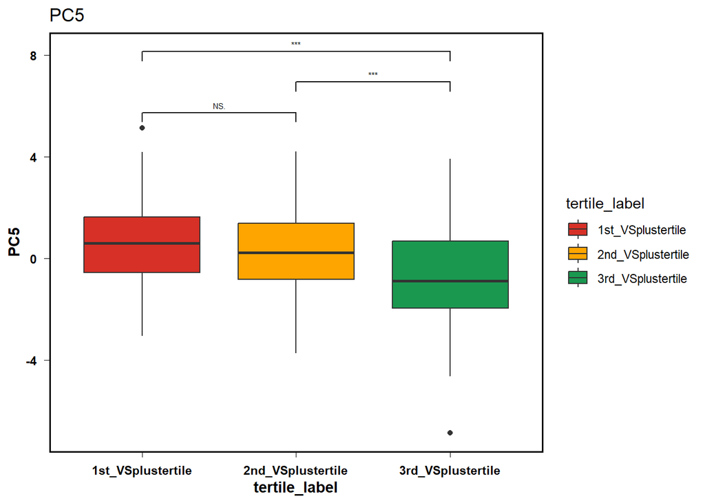

```r
p <- ggplot(spca_for_uni,
             aes_string(x = "tertile_label",y = "PC5",fill="tertile_label")) +
    geom_boxplot() +
    ggtitle("PC5") +
    theme_minimal() +
    scale_fill_manual(values = c("#D73027","orange","#1A9850")) +
    geom_signif(comparisons =
                  combn(as.character(unique(spca_for_uni$tertile_label)),
                        m=2, simplify = FALSE),
                map_signif_level = TRUE, step_increase = 0.1,textsize = 2)

p <- ggtheme(p)

p
```

## 3.5 SPCA loadings

Here, we will explore the loadings of the most important PC (**PC5**)

```r
load("../results/preprocessing/spca_result_vegans_INT_v3.RData")
df <- data.frame (
  Metabolite=names(spca_result$loadings$X[,5]),
  Loading=spca_result$loadings$X[,5])

write.table(df,sep="\t","../results/vegan/Q2_VStotal_plus/loadings_PC5.tsv")
```

This plot shows the loading of individual metabolites to **PC5**, ordered by its absolute value.

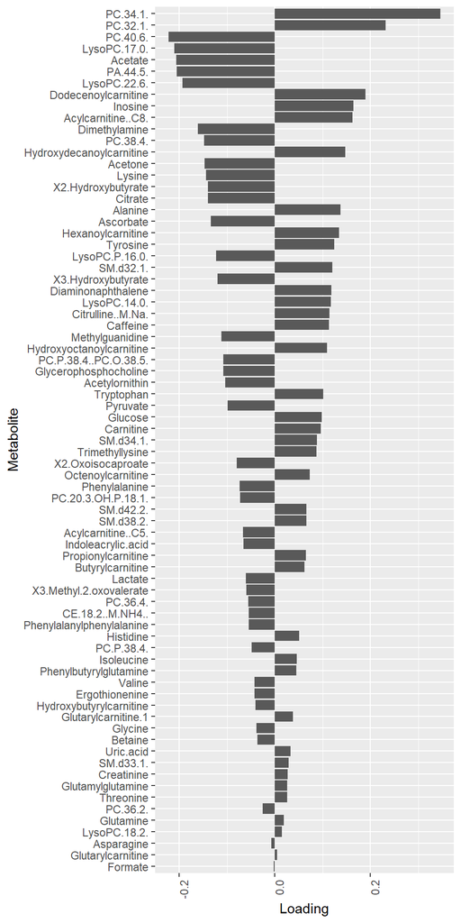

```r
ggplot(df %>%
         dplyr::mutate(
           Metabolite=factor(Metabolite,
                             levels = Metabolite[order(abs(Loading),decreasing = FALSE)])
           )) +
  geom_col(aes(x=Metabolite,y=Loading)) +
  theme(axis.text.x = element_text(angle=90,hjust = 1)) +
  coord_flip()
```

```r
spca_loadings <- df$Metabolite[abs(df$Loading)>=0.1]
```

# 4 Concatenated dataset

```r
concat_integrated_df <- cbind(lcms_df,nmr_df)
```

## 4.1 Visualization

### 4.1.1 Boxplots

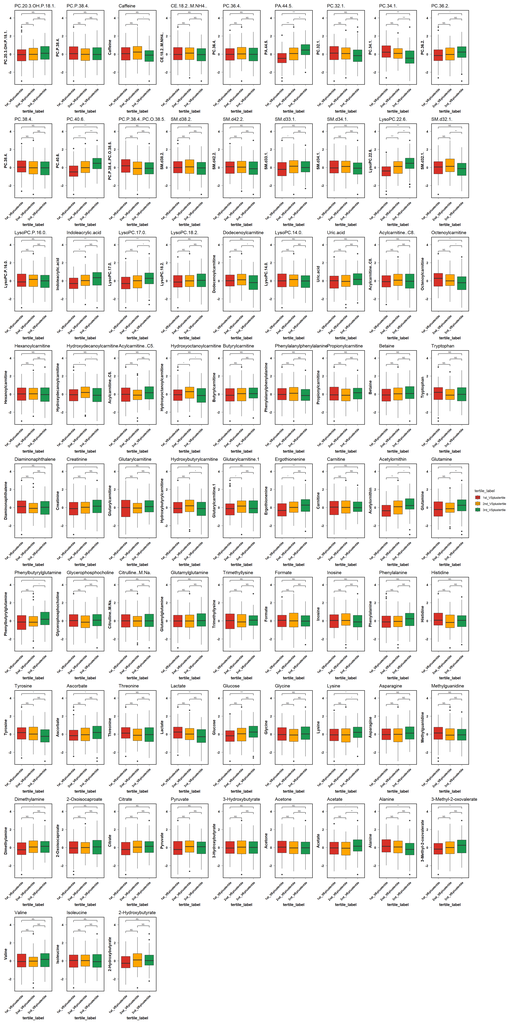

```r
concat_for_uni <- merge(concat_integrated_df %>% rownames_to_column("study_id"),
                      metadata_scaled_df,by="study_id",all = TRUE)

concat_for_uni <- concat_for_uni %>%
  mutate(
    tertile_cut = ntile(VS_total_plus, 3), # assign 1, 2, or 3 (tertile)
    tertile_label = case_when(                          # label tertiles
      tertile_cut == 1 ~ "1st_VSplustertile",
      tertile_cut == 2 ~ "2nd_VSplustertile",
      tertile_cut == 3 ~ "3rd_VSplustertile"
    )
  )

plot_list <- list()
for (col in colnames(concat_integrated_df)){
  p <- ggplot(concat_for_uni,
              aes(x = tertile_label,
                  y = !!sym(col),
                  fill=tertile_label)) +
    geom_boxplot() +
    ggtitle(col) +
    theme_minimal() +
    scale_fill_manual(values = c("#D73027","orange","#1A9850")) +
    geom_signif(comparisons =
                  combn(as.character(unique(concat_for_uni$tertile_label)),
                        m=2, simplify = FALSE),
                map_signif_level = TRUE, step_increase = 0.1,textsize = 2)

  p <- ggtheme(p) +
    theme(axis.text.x = element_text(angle=45,hjust = 1))
  plot_list[[length(plot_list) + 1]] <- p
}


a <- wrap_plots(plot_list,guides = "collect")

a
```

### 4.1.2 Heatmap

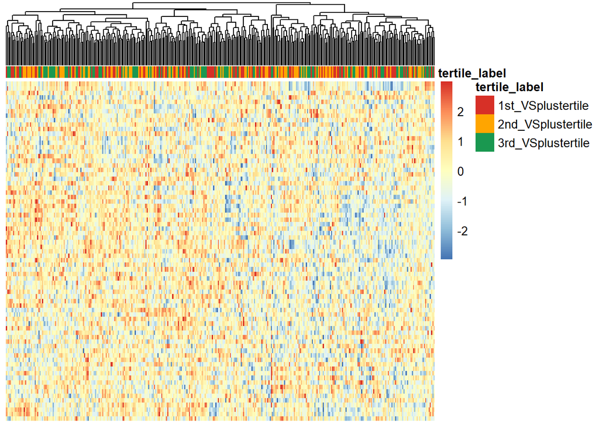

```r
metadata_df <- metadata_df %>%
  mutate(
    tertile_cut = ntile(VS_total_plus, 3), # assign 1, 2, or 3 (tertile)
    tertile_label = case_when(                          # label tertiles
      tertile_cut == 1 ~ "1st_VSplustertile",
      tertile_cut == 2 ~ "2nd_VSplustertile",
      tertile_cut == 3 ~ "3rd_VSplustertile"
    )
  ) %>%
  dplyr::select(-tertile_cut)
VS_colors <- c("1st_VSplustertile"="#D73027",
               "2nd_VSplustertile"="orange",
               "3rd_VSplustertile"="#1A9850")

p_df <- concat_integrated_df %>% t()

ann_df <- metadata_df %>% dplyr::select(study_id,tertile_label) %>%
  column_to_rownames("study_id")

ann_colors <- list(
  "tertile_label"=VS_colors
)
names(ann_colors[["tertile_label"]]) <- names(VS_colors)

p <- pheatmap(p_df,cluster_rows = FALSE,show_colnames = FALSE,
              show_rownames = FALSE,
              annotation_col = ann_df,
              annotation_colors = ann_colors,silent = TRUE)

p
```

## 4.2 Univariate analysis

We will test the differences between diets and VS total using generalize linear model while adjusting for covariates.

### 4.2.1 Continuous analysis

Call glm to explore which metabolites are significantly related to VS score while adjusting for age, sex, Country and dietary group:

Metabolite ~ sex + bmi + age + eq_vegan_dur_total + Country*VS_total_plus

```r
results_list <- lapply(colnames(concat_integrated_df),
                       function(x) fit_glm(x,concat_for_uni,
                                           tested_variable = "VS_total_plus"))
results_df <- do.call(rbind, results_list)

results_df$p_adjusted <- p.adjust(results_df$Pr...t..,method = "BH")
```

Look at significant results - **6 metabolites**

```r
results_df %>%
  dplyr::filter(p_adjusted<0.05) %>%
  dplyr::filter(variable=="VS_total_plus")
```

```
          metabolite      variable   Estimate Std..Error   t.value     Pr...t..
1           PA.44.5. VS_total_plus  0.3909323 0.09956441  3.926426 1.042854e-04
2           PC.40.6. VS_total_plus  0.3881690 0.09908414  3.917569 1.080191e-04
3          SM.d42.2. VS_total_plus -0.3128291 0.11128679 -2.811017 5.223104e-03
4       LysoPC.22.6. VS_total_plus  0.4570670 0.10074161  4.537024 7.908634e-06
5 Indoleacrylic.acid VS_total_plus  0.3992800 0.10468628  3.814063 1.621621e-04
6     Acetylornithin VS_total_plus  0.3678134 0.10806272  3.403703 7.437144e-04
   p_adjusted
1 0.001586952
2 0.001597465
3 0.038621542
4 0.000150983
5 0.002310340
6 0.007655883
```

Check the interaction effect - **Methylguanidine**

```r
df <- results_df %>%
  dplyr::filter(p_adjusted<0.05) %>%
  dplyr::filter(str_ends(variable, ":VS_total_plus"))

df
```

```
       metabolite                variable  Estimate Std..Error  t.value
1 Methylguanidine countryDE:VS_total_plus 0.3539462   0.130019 2.722265
     Pr...t.. p_adjusted
1 0.006815792 0.04708277
```

```r
pc_to_be_removed <- df$metabolite
```

```r
concat_significant_df <- (results_df %>%
  dplyr::filter(p_adjusted<0.05) %>%
  dplyr::filter(variable=="VS_total_plus"))

concat_univariate_results <- results_df

concat_significant <- (results_df %>%
  dplyr::filter(p_adjusted<0.05) %>%
  dplyr::filter(variable=="VS_total_plus"))$metabolite

# save and show
write.table(concat_significant_df,"../results/vegan/Q2_VStotal_plus/lm_continous.tsv",
            row.names = FALSE,
            quote=FALSE,
            sep="\t")

knitr::kable(concat_significant)
```

| x |
| --- |
| PA.44.5. |
| PC.40.6. |
| SM.d42.2. |
| LysoPC.22.6. |
| Indoleacrylic.acid |
| Acetylornithin |

```r
results_all <- (results_df %>%
  dplyr::filter(variable=="VS_total_plus"))

# save
write.table(results_all,"../results/vegan/Q2_VStotal_plus/lm_continous_all.tsv",
            row.names = FALSE,
            quote=FALSE,
            sep="\t")
```

**Volcano plot**

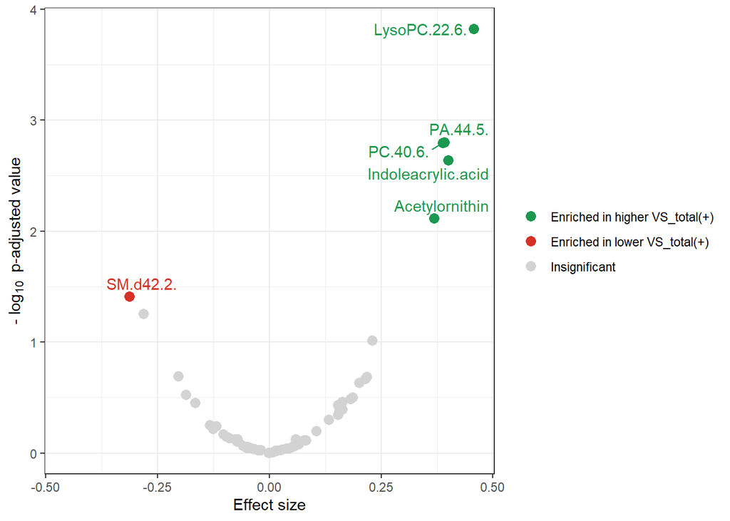

```r
vp <- volcano_plot(results_df,comparison = "VS_total_plus")
vp
```

**Correlation**

```r
sign <- (results_df %>%
  dplyr::filter(p_adjusted<0.05) %>%
  dplyr::filter(variable=="VS_total_plus"))$metabolite
```

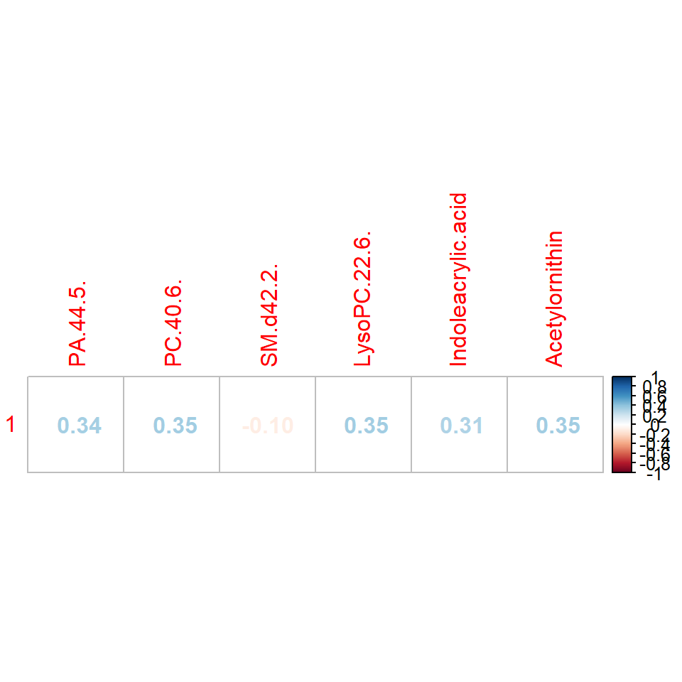

```r
df_for_plot <- concat_integrated_df %>% dplyr::select(sign)
corr_object <- cor(concat_for_uni$VS_total,df_for_plot)
corrplot::corrplot(corr_object,method = "number")
```

**Vegan duration**

```r
results_df %>%
  dplyr::filter(p_adjusted<0.05) %>%
  dplyr::filter(variable=="vegan_duration")
```

```
          metabolite       variable   Estimate Std..Error   t.value    Pr...t..
1          SM.d33.1. vegan_duration -0.1564241 0.05467217 -2.861128 0.004481018
2 Indoleacrylic.acid vegan_duration  0.1468340 0.05389264  2.724566 0.006769495
  p_adjusted
1 0.03432791
2 0.04707265
```

### 4.2.2 Pairwise analysis

Metab ~ sex + bmi + age + eq_vegan_dur_total + Country + tertile_label

**LM**

```r
results_list <- lapply(colnames(concat_integrated_df),
                       function(x) fit_netglm(x,concat_for_uni,
                                           tested_variable = "tertile_label"))
results_df <- do.call(rbind, results_list)

vs_effects <- results_df %>%
  dplyr::mutate(p_adj = p.adjust(`p.value`, method = "BH"))

concat_significant_cat <-  vs_effects %>%
  filter(p_adj < 0.05)

# save and show
write.table(concat_significant_cat,"../results/vegan/Q2_VStotal_plus/lm_cat.tsv",
            row.names = FALSE,
            quote=FALSE,
            sep="\t")

knitr::kable(concat_significant_cat)
```

| metabolite | tertile_label | emmean | p.value | lower.CL | upper.CL | p_adj |
| --- | --- | --- | --- | --- | --- | --- |
| PA.44.5. | 1st_VSplustertile | -0.4597119 | 0.0000001 | -0.6275408 | -0.2918830 | 0.0000298 |
| PC.34.1. | 1st_VSplustertile | 0.3037754 | 0.0008706 | 0.1258832 | 0.4816676 | 0.0156691 |
| PC.34.1. | 3rd_VSplustertile | -0.3552678 | 0.0001609 | -0.5383992 | -0.1721365 | 0.0041541 |
| PC.40.6. | 1st_VSplustertile | -0.3936670 | 0.0000053 | -0.5611405 | -0.2261934 | 0.0002004 |
| LysoPC.22.6. | 1st_VSplustertile | -0.4345973 | 0.0000009 | -0.6053222 | -0.2638724 | 0.0000995 |
| SM.d32.1. | 3rd_VSplustertile | -0.4175382 | 0.0000034 | -0.5914174 | -0.2436590 | 0.0001524 |
| Indoleacrylic.acid | 3rd_VSplustertile | 0.3080087 | 0.0010446 | 0.1247821 | 0.4912352 | 0.0156691 |
| Octenoylcarnitine | 3rd_VSplustertile | -0.3953155 | 0.0000017 | -0.5550467 | -0.2355844 | 0.0001291 |
| Hydroxydecanoylcarnitine | 2nd_VSplustertile | 0.2740202 | 0.0021333 | 0.0998471 | 0.4481932 | 0.0266660 |
| Hydroxyoctanoylcarnitine | 2nd_VSplustertile | 0.2779436 | 0.0021313 | 0.1012933 | 0.4545940 | 0.0266660 |
| Ergothionenine | 3rd_VSplustertile | 0.3084988 | 0.0010201 | 0.1253609 | 0.4916368 | 0.0156691 |
| Acetylornithin | 1st_VSplustertile | -0.3503191 | 0.0001662 | -0.5312900 | -0.1693482 | 0.0041541 |
| Acetylornithin | 3rd_VSplustertile | 0.3285842 | 0.0005885 | 0.1422835 | 0.5148850 | 0.0120384 |
| Formate | 1st_VSplustertile | 0.3060344 | 0.0000033 | 0.1787045 | 0.4333643 | 0.0001524 |
| Formate | 2nd_VSplustertile | 0.2121975 | 0.0009757 | 0.0867131 | 0.3376819 | 0.0156691 |
| Formate | 3rd_VSplustertile | 0.2425484 | 0.0003150 | 0.1114684 | 0.3736283 | 0.0070879 |
| Pyruvate | 3rd_VSplustertile | -0.2635829 | 0.0021270 | -0.4310731 | -0.0960927 | 0.0266660 |
| 3-Methyl-2-oxovalerate | 3rd_VSplustertile | 0.3497524 | 0.0000804 | 0.1773796 | 0.5221252 | 0.0025858 |
| 2-Hydroxybutyrate | 1st_VSplustertile | -0.2785479 | 0.0029855 | -0.4617507 | -0.0953451 | 0.0353545 |

```r
results_list_pairwise <- lapply(colnames(concat_integrated_df),
                       function(x) fit_netglm_pairwise(x,concat_for_uni,
                                           tested_variable = "tertile_label"))
results_df_pairwise <- do.call(rbind, results_list_pairwise)

vs_effects_pairwise <- results_df_pairwise %>%
  dplyr::mutate(p_adj = p.adjust(`p.value`, method = "BH"))

vs_significant_pairwise <-  vs_effects_pairwise %>%
  filter(p_adj < 0.05)
```

#### 4.2.2.1 Heatmap

```r
df2 <- vs_effects_pairwise %>%
  mutate(
    contrast = gsub("_VSplustertile", "", contrast),
    signif = p_adj < 0.05
  )

df2$Significance <- ifelse(df2$p_adj<0.001,"***",
                                       ifelse(df2$p_adj<0.01,"**",
                                              ifelse(df2$p_adj<0.05,"*","")))
```

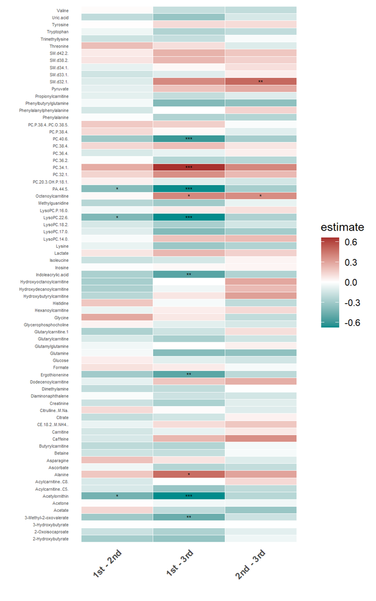

```r
p_pairwise_heatmap <- ggplot(df2, aes(x = contrast, y = Metabolite, fill = estimate)) +
  geom_tile(color = "white") +
  geom_text(aes(label = Significance,vjust=0.6), color = "black", size = 2) +
  scale_fill_gradient2(
    low = "darkcyan", mid = "white", high = "brown", midpoint = 0) +
  theme_minimal() +
  theme(axis.text.y = element_text(size=4),
        axis.text.x = element_text(angle = 45,face="bold",hjust = 1),
        panel.grid = element_blank()) +
  xlab("") + ylab("")

p_pairwise_heatmap
```

Network construction:

#### 4.2.2.2 Network construction

**Edge list**

```r
edges <- vs_effects %>%
  filter(p_adj < 0.05) %>%
  #filter(abs(emmean)>0.3) %>%
  dplyr::select(from = tertile_label, to = metabolite,
         emmean = emmean) %>%
  dplyr::mutate(from=as.character(from),
         weight=abs(emmean))

edges$from <- as.character(edges$from)
edges$to   <- as.character(edges$to)
```

**Nodes table**

```r
tertiles <- as.character(unique(edges$from))
metabs <- as.character(unique(edges$to))

nodes <- data.frame(
  name = c(tertiles, metabs),
  type = c(rep(TRUE, length(tertiles)), rep(FALSE, length(metabs))) # TRUE = tertile, FALSE = metabolite
)
```

**Build igraph object**

```r
g <- graph_from_data_frame(d = edges, vertices = nodes, directed = FALSE)
```

**Visualize**

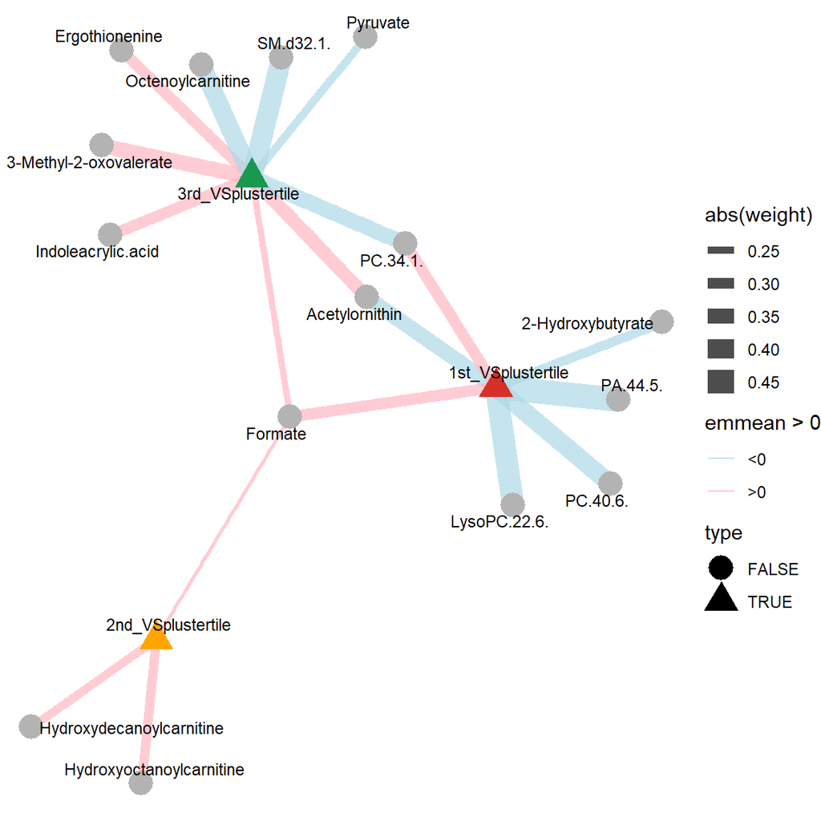

```r
VS_colors <- c("1st_VSplustertile"="#D73027",
               "2nd_VSplustertile"="orange",
               "3rd_VSplustertile"="#1A9850")

# Assign colors to nodes: countries get their color, metabolites gray
V(g)$color <- ifelse(V(g)$type,
                     VS_colors[V(g)$name],
                     "gray70")

set.seed(123)
ggraph(g, layout = "fr") +
  geom_edge_link(aes(width = abs(weight), color = emmean > 0), alpha = 0.7) +
  scale_edge_color_manual(values = c("lightblue", "lightpink"), labels = c("<0", ">0")) +
  geom_node_point(aes(shape=type,color = name), size = 6) +
  scale_color_manual(values = setNames(V(g)$color, V(g)$name)) +  # node colors
  geom_node_text(aes(label = name), repel = TRUE, size = 3) +
  theme_void() +
  guides(color = "none")
```

#### 4.2.2.3 Degree calculation

```r
# Calculate degree
deg <- degree(g, mode = "all")

# Add to node dataframe
node_degree_df <- data.frame(
  name = names(deg),
  degree = deg,
  type = V(g)$type
)

# Separate interpretation
vs_nodes <- node_degree_df %>% dplyr::filter(type == TRUE)
metabolite_nodes <- node_degree_df %>% dplyr::filter(type == FALSE)

vs_nodes %>% arrange(desc(degree))
```

```
                               name degree type
3rd_VSplustertile 3rd_VSplustertile      9 TRUE
1st_VSplustertile 1st_VSplustertile      7 TRUE
2nd_VSplustertile 2nd_VSplustertile      3 TRUE
```

```r
metabolite_nodes %>% arrange(desc(degree))
```

```
                                             name degree  type
Formate                                   Formate      3 FALSE
PC.34.1.                                 PC.34.1.      2 FALSE
Acetylornithin                     Acetylornithin      2 FALSE
PA.44.5.                                 PA.44.5.      1 FALSE
PC.40.6.                                 PC.40.6.      1 FALSE
LysoPC.22.6.                         LysoPC.22.6.      1 FALSE
SM.d32.1.                               SM.d32.1.      1 FALSE
Indoleacrylic.acid             Indoleacrylic.acid      1 FALSE
Octenoylcarnitine               Octenoylcarnitine      1 FALSE
Hydroxydecanoylcarnitine Hydroxydecanoylcarnitine      1 FALSE
Hydroxyoctanoylcarnitine Hydroxyoctanoylcarnitine      1 FALSE
Ergothionenine                     Ergothionenine      1 FALSE
Pyruvate                                 Pyruvate      1 FALSE
3-Methyl-2-oxovalerate     3-Methyl-2-oxovalerate      1 FALSE
2-Hydroxybutyrate               2-Hydroxybutyrate      1 FALSE
```

**Weighted degree** - Should reflect cumulative association magnitude, not just number of links.

```r
strength_vals <- strength(g, weights = E(g)$weight)

node_strength_df <- data.frame(
  name = names(strength_vals),
  strength = strength_vals,
  type = V(g)$type
)

# Separate interpretation
vs_nodes <- node_strength_df %>% dplyr::filter(type == TRUE)
metabolite_nodes <- node_strength_df %>% dplyr::filter(type == FALSE)

vs_nodes %>% arrange(desc(strength))
```

```
                               name  strength type
3rd_VSplustertile 3rd_VSplustertile 2.9690969 TRUE
1st_VSplustertile 1st_VSplustertile 2.5266529 TRUE
2nd_VSplustertile 2nd_VSplustertile 0.7641613 TRUE
```

```r
metabolite_nodes %>% arrange(desc(strength))
```

```
                                             name  strength  type
Formate                                   Formate 0.7607802 FALSE
Acetylornithin                     Acetylornithin 0.6789033 FALSE
PC.34.1.                                 PC.34.1. 0.6590432 FALSE
PA.44.5.                                 PA.44.5. 0.4597119 FALSE
LysoPC.22.6.                         LysoPC.22.6. 0.4345973 FALSE
SM.d32.1.                               SM.d32.1. 0.4175382 FALSE
Octenoylcarnitine               Octenoylcarnitine 0.3953155 FALSE
PC.40.6.                                 PC.40.6. 0.3936670 FALSE
3-Methyl-2-oxovalerate     3-Methyl-2-oxovalerate 0.3497524 FALSE
Ergothionenine                     Ergothionenine 0.3084988 FALSE
Indoleacrylic.acid             Indoleacrylic.acid 0.3080087 FALSE
2-Hydroxybutyrate               2-Hydroxybutyrate 0.2785479 FALSE
Hydroxyoctanoylcarnitine Hydroxyoctanoylcarnitine 0.2779436 FALSE
Hydroxydecanoylcarnitine Hydroxydecanoylcarnitine 0.2740202 FALSE
Pyruvate                                 Pyruvate 0.2635829 FALSE
```

#### 4.2.2.4 Top-group assignment

**All together**

```r
VS_colors <- c("1st_VSplustertile"="#D73027",
               "2nd_VSplustertile"="orange",
               "3rd_VSplustertile"="#1A9850",
               "other"="gray70")

# Assign colors to nodes: countries get their color, metabolites gray
V(g)$color <- ifelse(V(g)$type,
                     VS_colors[V(g)$name],
                     "gray70")

top_group <- edges %>%
  dplyr::group_by(to) %>%
  slice_max(order_by = abs(weight), n = 1, with_ties = FALSE) %>%
  dplyr::select(from,to, weight) %>%
  ungroup()

top_group
```

```
# A tibble: 15 × 3
   from              to                       weight
   <chr>             <chr>                     <dbl>
 1 1st_VSplustertile 2-Hydroxybutyrate         0.279
 2 3rd_VSplustertile 3-Methyl-2-oxovalerate    0.350
 3 1st_VSplustertile Acetylornithin            0.350
 4 3rd_VSplustertile Ergothionenine            0.308
 5 1st_VSplustertile Formate                   0.306
 6 2nd_VSplustertile Hydroxydecanoylcarnitine  0.274
 7 2nd_VSplustertile Hydroxyoctanoylcarnitine  0.278
 8 3rd_VSplustertile Indoleacrylic.acid        0.308
 9 1st_VSplustertile LysoPC.22.6.              0.435
10 3rd_VSplustertile Octenoylcarnitine         0.395
11 1st_VSplustertile PA.44.5.                  0.460
12 3rd_VSplustertile PC.34.1.                  0.355
13 1st_VSplustertile PC.40.6.                  0.394
14 3rd_VSplustertile Pyruvate                  0.264
15 3rd_VSplustertile SM.d32.1.                 0.418
```

```r
top_group_viz <- rbind(top_group,
                       data.frame(
                         from=unique(edges$from),
                         to=unique(edges$from),
                         weight=NA))

membership_df <- data.frame(
  vertex = top_group_viz$to,
  cluster = top_group_viz$from)

membership_df <- membership_df %>% arrange(match(vertex,names(V(g))))
```

```r
vs_clusters <- (membership_df %>%
  group_by(cluster) %>%
  summarise(metabolites = paste(unique(vertex), collapse = ", ")))[1:3,]

(membership_df %>%
  group_by(cluster) %>%
  summarise(Number_of_metabolites = length(unique(vertex))-1))[1:3,]
```

```
# A tibble: 3 × 2
  cluster           Number_of_metabolites
  <chr>                             <dbl>
1 1st_VSplustertile                     6
2 2nd_VSplustertile                     2
3 3rd_VSplustertile                     7
```

```r
vs_clusters
```

```
# A tibble: 3 × 2
  cluster           metabolites
  <chr>             <chr>
1 1st_VSplustertile 1st_VSplustertile, PA.44.5., PC.40.6., LysoPC.22.6., Acetyl…
2 2nd_VSplustertile 2nd_VSplustertile, Hydroxydecanoylcarnitine, Hydroxyoctanoy…
3 3rd_VSplustertile 3rd_VSplustertile, PC.34.1., SM.d32.1., Indoleacrylic.acid,…
```

```r
V(g)$fill <- VS_colors[membership_df$cluster]
V(g)$color <- VS_colors[membership_df$cluster]
```

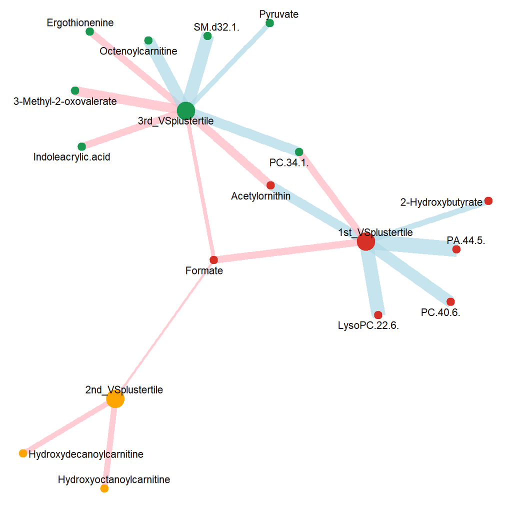

```r
set.seed(123)
p_all <- ggraph(g, layout = "fr") +
  geom_edge_link(aes(width = abs(weight), color = emmean > 0), alpha = 0.7) +
  scale_edge_color_manual(values = c("lightblue","lightpink"),labels = c("<0", ">0")) +
  geom_node_point(aes(size=type,color = name,fill=name),shape=21,stroke=1.2) +
  scale_color_manual(values = setNames(V(g)$color, V(g)$name))   + # node colors
  scale_fill_manual(values = setNames(V(g)$fill, V(g)$name)) +  # node fill
  geom_node_text(aes(label = name), repel = TRUE, size = 3) +
  theme_void() +
  theme(legend.position = "none")


p_all
```

# 5 Final significant metabolites

```r
list_core <- list()
list_core[["concat_univariate"]] <- unique(concat_significant)
```

```r
final_significance <- list_core[["concat_univariate"]]
final_significance
```

```
[1] "PA.44.5."           "PC.40.6."           "SM.d42.2."
[4] "LysoPC.22.6."       "Indoleacrylic.acid" "Acetylornithin"
```

# 6 Metabolite-based Veganscreener score (+)

## 6.1 Continuous univariate test

To create a vegan index based on concatenated dataset, we will use linear regression in order to get coefficients on significant variables that were revealed across the analysis:

```r
sign <- final_significance
sign
```

```
[1] "PA.44.5."           "PC.40.6."           "SM.d42.2."
[4] "LysoPC.22.6."       "Indoleacrylic.acid" "Acetylornithin"
```

```r
# define the variables
plot_list <- list()
rhos <- rep(NA,5)

# split the datasets for cross-validation
concat_for_index <- concat_for_uni[sample(rownames(concat_for_uni)),]
cv_splits <- cv_folds(concat_for_index,folds = 5)

final_df_veganindex <- data.frame()

# cross validation loop
vars_selection <- list()
for (i in 1:length(cv_splits)){
  unisub_df <- concat_for_uni[cv_splits[[i]]$train,]
  results_list <- lapply(colnames(concat_integrated_df),
                       function(x) fit_glm(x,unisub_df,
                                           tested_variable = "VS_total_plus"))
  results_df <- do.call(rbind, results_list)

  results_df$p_adjusted <- p.adjust(results_df$Pr...t..,method = "BH")

  vars <- results_df$metabolite[results_df$p_adjusted<0.05 & results_df$variable=="VS_total_plus"]
  vars_selection[[i]] <- vars

  # Wrap all variable names in backticks
  vars_safe <- paste0("`", vars, "`")

  fml <- as.formula(paste("VS_total_plus ~", paste(vars_safe, collapse = " + ")))

  # fit the model
  model <- lm(fml, unisub_df)

  # predict the result on validation dataset
  VG_index <- stats::predict(model,concat_for_uni[cv_splits[[i]]$val,])

  # store the predicted index
  sub_df <- concat_for_uni[cv_splits[[i]]$val,]
  sub_df$VGindex <- VG_index
  final_df_veganindex <- rbind(final_df_veganindex,sub_df)

  # calculate correlation
  cor_test <- cor.test(sub_df$VGindex,
               sub_df$VS_total_plus,
               method = "spearman")
  cor_val <- cor_test$estimate
  if (cor_test$p.value >0.05) cor_val = 0

  # plot the result
  p <- ggplot(sub_df,
              aes_string(x = "VGindex", y = "VS_total_plus"),
              color="blue") +
       geom_point() +
    geom_smooth(method = "lm") +
    theme_minimal() +
    ggtitle(paste("Rho =",round(cor_val,2)))

  plot_list[[i]] <- p
  rhos[i] <- round(cor_val,2)

}
```

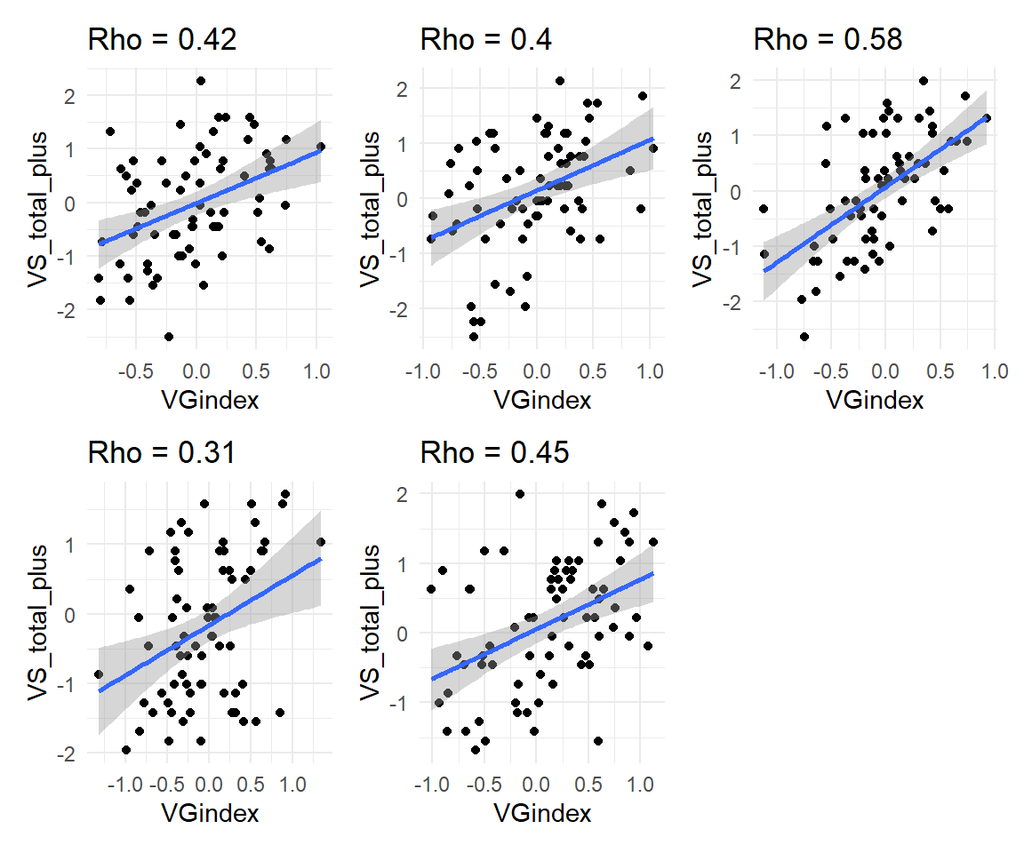

```r
wrap_plots(plot_list)
```

```r
mean(rhos)
```

```
[1] 0.432
```

```r
# calculate correlation
  cor_test <- cor.test(final_df_veganindex$VGindex,
               final_df_veganindex$VS_total_plus,
               method = "spearman")
  cor_val <- cor_test$estimate
  if (cor_test$p.value >0.05) cor_val = 0

  # plot the result
  p <- ggplot(final_df_veganindex,
              aes_string(x = "VGindex", y = "VS_total_plus")) +
       geom_point() +
    geom_smooth(method = "lm",color="blue") +
    theme_minimal() +
    ggtitle(paste("Rho =",round(cor_val,2))) +
    xlab("Metabite-based Vegan score (+)") +
    ylab("Vegan score (+) (z-scored)")

p <- ggtheme(p)
```

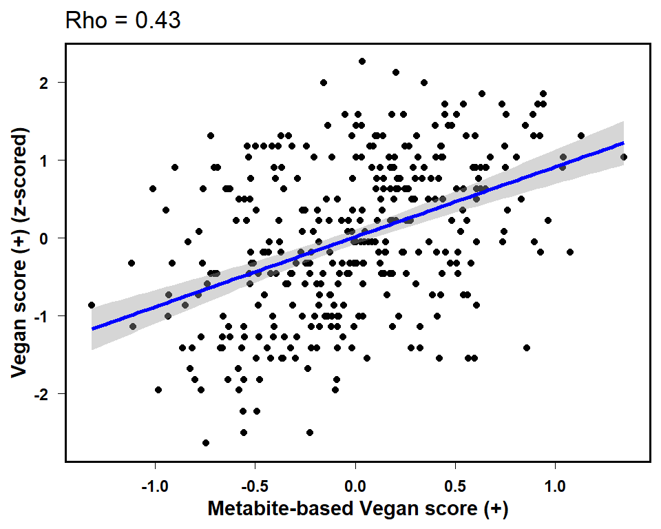

```r
p
```

```r
f <- p + ggtitle("")
save(f,file="../results/vegan/figures/FS_VMI_plus.RData")
```

# 7 Plot for publication

## 7.1 Heatmap

### 7.1.1 Continuous

```r
ordered_participants <- metadata_df %>%
  dplyr::arrange(VS_total)

concat_significant_df <- concat_significant_df %>%
  dplyr::filter(metabolite %in% final_significance) %>%
  dplyr::arrange(Estimate)

heatmap_concat_integrated_df <- concat_integrated_df

heatmap_concat_integrated_df <- heatmap_concat_integrated_df[as.character(ordered_participants$study_id),
                             as.character(concat_significant_df$metabolite)]

# Create a grouping variable for each block of 10 rows
group_id <- rep(1:ceiling(nrow(heatmap_concat_integrated_df) / 10), each = 10,
                length.out = nrow(heatmap_concat_integrated_df))

# Calculate the mean for each group
df_grouped <- aggregate(heatmap_concat_integrated_df,
                        by = list(Group = group_id), FUN = median)

# Remove the Group column name prefix if you want just the values
rownames(df_grouped) <- paste0("Group_", df_grouped$Group)
df_grouped$Group <- NULL
```

```r
df_long <- df_grouped %>% t() %>% as.data.frame() %>%
  rownames_to_column("Metabolite") %>%
  pivot_longer(cols = -Metabolite, names_to = "Participant", values_to = "value")

df_long$Metabolite <- factor(df_long$Metabolite, levels=concat_significant_df$metabolite)
df_long$Participant <- factor(as.character(df_long$Participant), levels=paste0("Group_",1:37))


p_heat <- ggplot(df_long, aes(x = Participant, y = Metabolite, fill = value)) +
  geom_tile(color = "white",width=1) +
  theme_minimal() +
  theme(axis.text.x = element_blank(),
        axis.title.x = element_text(face = "bold",size = 9),
        axis.text.y = element_blank(),
        panel.grid = element_blank(),
        legend.position = "right") +
  labs(fill = "Median metabolite z-score") +
  xlab("Vegans (ordered and grouped by VS_total)") +
  ylab("") +
  scale_fill_gradient2(
    low = "darkcyan", mid = "white", high = "brown", midpoint = 0)

# get legend
leg_heat_p <- ggpubr::get_legend(p_heat)

# remove legend
p_heat <- p_heat + theme(legend.position = "none")
```

```r
annotation_df <- concat_significant_df
#annotation_df$metabolite <- c("Phosphatidylcholine (34:1)",
#                              "Sphingomyelin (d42:2)",
                             #  "Octenoylcarnitine",
                             # "Lysophosphatidylcholine (17:0)",
                             # "Indoleacrylic acid",
                             # "Ergothioneine",
                             # "Phosphatidic acid (44:5)",
                             # "Phosphatidylcholine (40:6)",
                             # "Acetylornithin",
                             # "Lysophosphatidylcholine (22:6)")

# annotation_df$metabolite <- c("Phosphatidylcholine (34:1)",
#                               "Sphingomyelin (d42:2)",
#                               "Glutarylcarnitine",
#                              "Lysophosphatidylcholine (17:0)",
#                              "Indoleacrylic acid",
#                              "Phosphatidic acid (44:5)",
#                              "Acetylornithin",
#                              "Phosphatidylcholine (40:6)",
#                              "Lysophosphatidylcholine (22:6)")
annotation_df$metabolite <- factor(annotation_df$metabolite,
                                   levels=annotation_df$metabolite)


ann_p <- ggplot(
  data=annotation_df,
  aes(x = "Estimate", y = metabolite, fill = Estimate)) +
  geom_tile(color = "white") +
  scale_fill_gradient2(low = "#313695", mid = "white", high = "#A50026", midpoint = 0) +
  theme_minimal() +
  theme(axis.text.y = element_text(face = "bold"),
        axis.text.x = element_blank(),
        axis.title.y= element_text(face = "bold"),
        axis.ticks = element_blank(),
        panel.grid = element_blank(),
        legend.position = "right") +
  ylab("Significant metabolites") +
  xlab("") +
  labs(fill="LM estimate")

# get legend
leg_ann_p <- ggpubr::get_legend(ann_p)

# Remove legend from the original plot
ann_p <-ann_p + theme(legend.position = "none")
```

```r
# correlations
df_for_plot <- concat_integrated_df %>% dplyr::select(final_significance)
df_for_plot <- df_for_plot[,concat_significant_df$metabolite]
corr_object <- cor(concat_for_uni$VS_total,df_for_plot,method="spearman")
corr_df <- data.frame(Metabolite=colnames(corr_object),
                      Rho=corr_object[1,])
corr_df$Metabolite <- factor(corr_df$Metabolite,
                             levels=corr_df$Metabolite)

p_corr <- ggplot(corr_df) +
  geom_point(aes(x="Rho",y= Metabolite,size = abs(Rho), fill = Rho, color=Rho),
             shape = 21) +
  scale_fill_gradient2(name = "Rho",
                       low = "blue", mid = "white", high = "red", midpoint = 0) +
    scale_color_gradient2(name = "Rho",
                          low = "blue", mid = "white",
                          high = "red", midpoint = 0) +
  guides(size = "none") +
  theme_minimal() +
  theme(axis.text.y = element_blank(),
        axis.text.x = element_blank(),
        axis.title.y= element_blank(),
        axis.ticks = element_blank(),
        panel.grid = element_blank(),
        legend.position = "right") +
  xlab("")


leg_corr_p <- ggpubr::get_legend(p_corr)

# Remove legend from the original plot
p_corr <-
  p_corr +
  theme(
    legend.position = "none")
```

```r
legends <- ggarrange(leg_heat_p, leg_ann_p, leg_corr_p,nrow = 3, align = "hv")

p <- wrap_plots(ann_p,p_corr,p_heat,legends,ncol=4,widths = c(0.1,0.15, 1, 1))
```

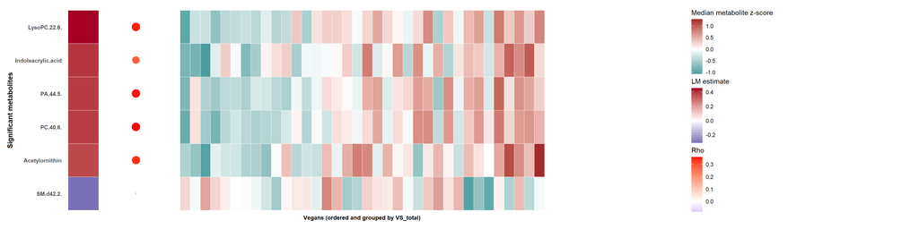

```r
p
```

### 7.1.2 Pairwise

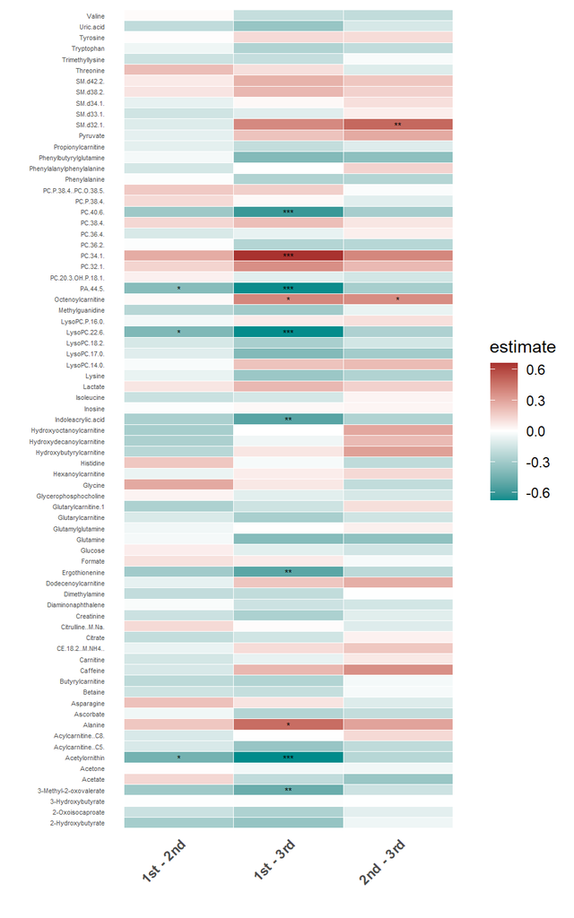

```r
p_pairwise_heatmap
```

## 7.2 Forest plot

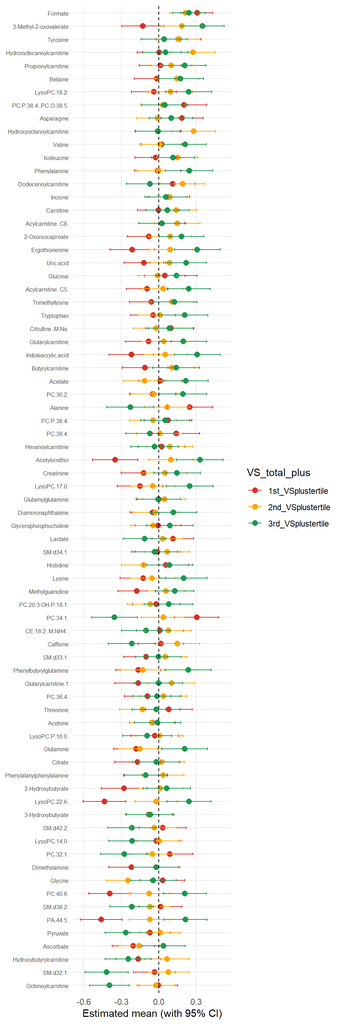

```r
# Define custom colours
VS_colors <- c("1st_VSplustertile"="#D73027",
               "2nd_VSplustertile"="orange",
               "3rd_VSplustertile"="#1A9850")

# Optional: order metabolites by mean effect size
forest_df <- vs_effects %>%
  group_by(metabolite) %>%
  mutate(mean_eff = mean(emmean)) %>%
  ungroup()

forest_df$metabolite <- factor(
  forest_df$metabolite,
  levels = forest_df %>%
    arrange(mean_eff) %>%
    pull(metabolite) %>%
    unique()
)

# Forest plot WITHOUT ANY TEXT LABELS
p_forest <- ggplot(forest_df,
                   aes(x = emmean,
                       y = metabolite,
                       color = tertile_label)) +

  geom_point(size = 2.5) +
  geom_errorbarh(aes(xmin = lower.CL, xmax = upper.CL), height = 0.2) +
  geom_vline(xintercept = 0, linetype = "dashed") +

  scale_color_manual(values = VS_colors) +

  theme_minimal() +
  theme(axis.title.y = element_blank(),
        axis.text.y = element_text(size = 6),
        panel.grid.minor = element_blank()) +

  labs(
    x = "Estimated mean (with 95% CI)",
    color = "VS_total_plus"
  )

p_forest
```

## 7.3 Network

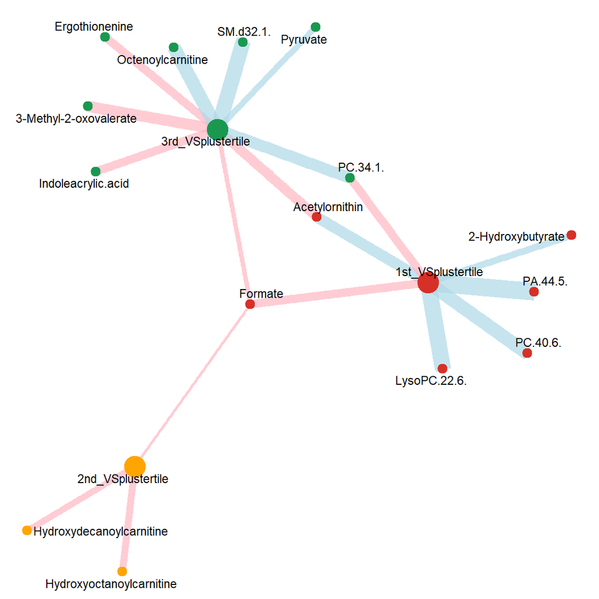

```r
p_all
```